# Redlining and Health Outcomes in Jackson, MS

Sarah Bolongaita, Hae In Kim, Christina Scaduto, Lily Shay

# Overview and Motivation

Too often historical policies are dismissed as unimportant and no longer having an impact in the present day. Time and again, research and evidence have illustrated this to be untrue and we want to demonstrate this using data science tools obtained in this course.

Our project examines the relationship between redlining in Jackson, MS and various health indicators and outcomes. As a part of FDR’s New Deal, a federal agency known as the Home Owners’ Loan Corporation implemented the redlining practice in many cities across the United States. Neighborhoods were “evaluated” based on their “mortgage security” and areas that posed the lowest risks were graded “A” or “Best.” Neighborhoods with the “highest risk” were graded “D” or “Hazardous.” These evaluations were racist and inflicted even more structural violence in communities of color.

Under redlining it was impossible for people of color to receive mortgage loans to purchase homes in A/B graded neighborhoods (“Best,” “Still Desirable”). In the US, owning property is considered the most significant way to generate intergenerational wealth and redlining prevented this for many families of color across the US. Evaluating areas with low property value also deflected investment in public goods, such as public schools that are typically paid for by property taxes. Additionally, businesses were also unable to receive insurance in C/D graded neighborhoods, perpetuating divestment and decreasing access to resources (i.e., health care systems, grocery stores, etc.).

In short, redlining was government-sanctioned segregation.

While the Fair Housing Act of 1968 made formal redlining illegal, it did not create a mechanism to undo past harms. The lack of investment in and divestment from these communities has largely gone uncorrected and continues to shape Jackson.

By comparing the HOLC grades that were assigned in the 1930s to health data from the past 10 years, we hope to illuminate that the harm redlining imposed on these neighborhoods is not a thing of the past, but lingers to the present day.

# Related Work

The project stemmed from preliminary research that a group member, Lily Shay, conducted for a summer practicum. Her practicum focused specifically on the impact of redlining in Jackson, MS on food insecurity and relevant health outcomes.

This project builds on Lily’s project by expanding the data set to include multi-year data and explore other the relationship between redlining and other health related measures.

# Initial Questions

At the beginning of this project, we aimed to demonstrate the relationship between redlining and health outcomes (specifically related to food security). We also wanted to explore how redlining impacted structural factors such as healthy food availability which in turn impacts health outcomes for a population.

Finally, we were hoping to look at how redlining affected different populations differentially based on race/ethnicity. Other potential questions included looking at redlined areas and home valuation and area median income over time per census tract.

# How the questions evolved

Our group initially ran into challenges pulling multi-year data from the City Health Dashboard. We turned to the 500 Cities Project data - the source of data that the Dashboard pulls from.

In addition to this, we had trouble parsing out demographic data related to the census tracts that we were looking at. Because of this, we decided to forgo our questions regarding the differential effect of redlining based on race/ethnicity and area median income.

We conducted exploratory data analysis on these measures and their relationship to HOLC grades. We found that most of the associations were significant. With this in mind, we decided to focus on current lack of health insurance, obesity, diabetes, and mental health.

# Data

## Data Sources

Data was obtained from [City Health Dashboard](https://www.cityhealthdashboard.com/) and the [CDC’s 500 Cities Project Data](https://www.cdc.gov/500cities/index.htm). The 500 Cities Project is a collaboration between the Robert Wood Johnson Foundation and the CDC Foundation. The 500 Cities Project provides city and census tract-level small area estimates for health outcomes.

The HOLC data and shapefiles were obtained from the [University of Richmond’s Mapping Inequality project](https://dsl.richmond.edu/panorama/redlining/#loc=5/39.1/-94.58).

For all graphs, HOLC grades are interpreted as follows: A: ‘Best’ B: ‘Still Desirable’ C: ‘Definitely Declining’ D: ‘Hazardous’

## Data Cleanup

Health measure data was acquired at a census tract-level for Jackson, MS from the 500 Cities Projects Data. Data from 4 different years were compiled into one data frame. Mismatched names between data frames were checked and addressed. Data frames were sorted by year, measure and ID.

Since HOLC graded areas do not perfectly coincide with census tracts, initial spatial analysis was done in ArcGIS to establish what percentage of the HOLC graded areas were within each census tract.

The two datasets (HOLC/spatial analysis and 500 Cities) were combined in a dataframe in two formats. The long frame includes each census tract in Jackson, MS while the short frame combined the grades to aggregate is a census tract held more positive HOLC grades (A/B) or negative HOLC grades (C/D).

Looking through the list of 28 measures, we realized that not all measures were collected every year. We chose 4 to focus on - health insurance, obesity, diabetes, and mental health. These indicators were collected in the same years - 2014, 2015, and 2017.

### Loading Packages

```r
# Creating a function for loading packages
ipak <- function(pkg){
    new.pkg <- pkg[!(pkg %in% installed.packages()[, "Package"])]
    if (length(new.pkg))
        install.packages(new.pkg, dependencies = TRUE)
    sapply(pkg, require, character.only = TRUE)
}

# Loading packages
packages <- c("dplyr", "DT", "foreign", "ggplot2", "ggthemes", "Gmisc", "Hmisc", "janitor", "maditr",
              "readr", "readxl", "reshape", "rsconnect", "stringr", "tidyr")
ipak(packages)
```

```
##     dplyr        DT   foreign   ggplot2  ggthemes     Gmisc     Hmisc
##      TRUE      TRUE      TRUE      TRUE      TRUE      TRUE      TRUE
##   janitor    maditr     readr    readxl   reshape rsconnect   stringr
##      TRUE      TRUE      TRUE      TRUE      TRUE      TRUE      TRUE
##     tidyr
##      TRUE
```

```r
# Clearing environment
rm(list = ls())

# Setting working directory
```

### Health Data

#### Compiling datasets published from 2016-2019

```r
# Loading data for available years
df.2016 <- read_csv("500_Cities__Local_Data_for_Better_Health__2016_release.csv")
df.2017 <- read_csv("500_Cities__Local_Data_for_Better_Health__2017_release.csv")
df.2018 <- read_csv("500_Cities__Local_Data_for_Better_Health__2018_release.csv")
df.2019 <- read_csv("500_Cities__Local_Data_for_Better_Health__2019_release.csv")

# Comparing dfs
comparison <- compare_df_cols(df.2016, df.2017, df.2018, df.2019)

# Fixing mismatched names
df.2016 <- df.2016 %>% dplyr::rename("PopulationCount" = Population2010)
df.2017 <- df.2017 %>% dplyr::rename("PopulationCount" = Population2010)
df.2018 <- df.2018 %>% dplyr::rename("GeoLocation" = Geolocation)

# Saving original variable order
original <- names(df.2016)

# Sorting variable order alphabetically
sorted <- sort(names(df.2016))

# Sorting all df columns alphabetically in preparation of rbind
df_2016 <- df.2016 %>% select(sorted)
df_2017 <- df.2017 %>% select(sorted)
df_2018 <- df.2018 %>% select(sorted)
df_2019 <- df.2019 %>% select(sorted)

# Binding dfs
df <- rbind(df.2016, df.2017, df.2018, df.2019)

# Filtering data and removing rows with constant values
df <- df %>%
  filter(GeographicLevel == "Census Tract",
         !str_detect(GeoLocation, "POINT"),
         !is.na(TractFIPS)) %>%
  remove_constant()

# Creating final 500Cities dataframes
`500cities.unspread` <- df %>%
  select(TractFIPS, Year, MeasureId, Short_Question_Text, Measure, Data_Value) %>%
  distinct()
`500cities` <- df %>%
  select(TractFIPS, Year, MeasureId, Data_Value) %>%
  distinct() %>%
  spread(MeasureId, Data_Value)

# Removing unneeded dfs
rm(comparison, df.2016, df.2017, df.2018, df.2019)
```

#### Creating a reference dataframe for measures

```r
# Generating metadata file  of measures
temp1 <- df %>%
  select(MeasureId, Short_Question_Text, Measure) %>%
  distinct() %>%
  arrange(MeasureId)

# Getting the years of data for each measure
temp2 <- df %>%
  select(MeasureId, Year) %>%
  group_by(MeasureId) %>%
  distinct() %>%
  arrange(MeasureId, Year) %>%
  summarise(Years = paste(Year, collapse = ", "))

# Joining dataframes
metrics <- left_join(temp1, temp2)

# Removing unneeded dfs
rm(df, temp1, temp2)
```

### HOLC Grades Data

#### Combining HOLC data with spatial data

```r
# Loading HOLC data
df <- read_xlsx("MS_Data\ Summary.xlsx", sheet = 1)

# Selecting variables
df <- df %>%
  select(CensusTracts, holc_id, holc_grade) %>%
  dplyr::rename("TractFIPS" = CensusTracts,
                "HOLC_Id" = holc_id,
                "HOLC_Grade" = holc_grade)

# Loading spatial data to get percent of census tract land by grade
df2 <- read.dbf("Pct_Holc.dbf")

# Selectng variables
df2 <- df2 %>%
  select(tract2010, holc_id, PERCENTAGE) %>%
  mutate(tract2010 = as.numeric(as.character(tract2010)),
         PERCENTAGE = round(PERCENTAGE / 100, 6)) %>%
  dplyr::rename("TractFIPS" = tract2010,
                "HOLC_Id" = holc_id,
                "HOLC_Pct" = PERCENTAGE)

# Joining HOLC and spatial data
df3 <- left_join(df, df2, by = c("TractFIPS", "HOLC_Id"))
```

#### Combining HOLC/spatial data with 500 cities data: Extra long format (for dynamic Shiny plot)

```r
# Joining HOLC/spatial data with unspread 500 cities data
data_xlong <- left_join(`500cities.unspread`, df3)
data_xlong <- data_xlong %>%
  select(TractFIPS, HOLC_Grade, HOLC_Pct, Year, MeasureId, Short_Question_Text, Measure, Data_Value) %>%
  distinct()

# Defining exposure variable - Only including grades that composed more than 30% of the census tract's land
data_xlong <- data_xlong %>%
  mutate(HOLC_Pct2 = ifelse(HOLC_Pct > 0.3, round(HOLC_Pct * 100, 2), NA),
         HOLC_Grade2 = ifelse(is.na(HOLC_Pct2), NA, HOLC_Grade),
         HOLC_Grade3 = factor(ifelse(is.na(HOLC_Grade2), 1,
                                     ifelse(HOLC_Grade2 == "A", 2,
                                            ifelse(HOLC_Grade2 == "B", 3,
                                                   ifelse(HOLC_Grade2 == "C", 4,
                                                          ifelse(HOLC_Grade2 == "D", 5, NA))))),
                              levels = 1:5,
                              labels = c("No grade", "A", "B", "C", "D"))) %>%
  select(-HOLC_Grade, -HOLC_Pct, -HOLC_Grade2) %>%
  dplyr::rename("HOLC_Pct" = HOLC_Pct2,
         "HOLC_Grade" = HOLC_Grade3) %>%
  select(TractFIPS, HOLC_Grade, HOLC_Pct, Year, MeasureId, Short_Question_Text, Measure, Data_Value) %>%
  distinct()
```

#### Combining HOLC/spatial data with 500 cities data: Long format

```r
# Joining HOLC/spatial data with 500 cities data
data_long <- left_join(`500cities`, df3)
data_long <- data_long %>%
  select(TractFIPS, Year, HOLC_Grade, HOLC_Pct, ACCESS2:TEETHLOST)

# Defining exposure variable - Only including grades that composed more than 30% of the census tract's land
data_long <- data_long %>%
  mutate(HOLC_Pct2 = ifelse(HOLC_Pct > 0.3, round(HOLC_Pct * 100, 2), NA),
         HOLC_Grade2 = ifelse(is.na(HOLC_Pct2), NA, HOLC_Grade),
         HOLC_Grade3 = factor(ifelse(is.na(HOLC_Grade2), 1,
                                     ifelse(HOLC_Grade2 == "A", 2,
                                            ifelse(HOLC_Grade2 == "B", 3,
                                                   ifelse(HOLC_Grade2 == "C", 4,
                                                          ifelse(HOLC_Grade2 == "D", 5, NA))))),
                              levels = 1:5,
                              labels = c("No grade", "A", "B", "C", "D"))) %>%
  select(-HOLC_Grade, -HOLC_Pct, -HOLC_Grade2) %>%
  dplyr::rename("HOLC_Pct" = HOLC_Pct2,
         "HOLC_Grade" = HOLC_Grade3) %>%
  select(TractFIPS, HOLC_Grade, HOLC_Pct, Year, ACCESS2:TEETHLOST) %>%
  distinct()
```

#### Combining HOLC/spatial data with 500 cities data: Short format

```r
# Compiling HOLC grades by census tract
df4 <- df3 %>%
  group_by(TractFIPS) %>%
  dplyr::summarize(HOLC_Grades = paste(unique(HOLC_Grade), collapse = ", "))

# Getting the percent of census tract land graded positive
df4.pos <- df3 %>%
  filter(HOLC_Grade == "A" | HOLC_Grade == "B") %>%
  group_by(TractFIPS) %>%
  dplyr::summarize(HOLC_Pos_Pct = round(sum(HOLC_Pct) * 100, 2))

# Getting the percent of census tract land graded negative
df4.neg <- df3 %>%
  filter(HOLC_Grade == "C" | HOLC_Grade == "D") %>%
  group_by(TractFIPS) %>%
  dplyr::summarize(HOLC_Neg_Pct = round(sum(HOLC_Pct) * 100, 2))

# Joining dfs
df5 <- left_join(df4, df4.pos)
df5 <- left_join(df5, df4.neg)

# Defining categorical exposure variables
df5 <- df5 %>%
  mutate(HOLC_Pos = as.numeric(str_detect(HOLC_Grades, "A|B")),
         HOLC_Neg = as.numeric(str_detect(HOLC_Grades, "C|D")),
         HOLC_Contains = factor(ifelse(HOLC_Pos == 1 & HOLC_Neg == 0, 1,
                                       ifelse(HOLC_Pos == 0 & HOLC_Neg == 1, 2,
                                              ifelse(HOLC_Pos == 1 & HOLC_Neg == 1, 3, NA))),
                                levels = 1:3,
                                labels = c("Positive", "Negative", "Both")),
         HOLC_Majority = factor(ifelse(HOLC_Pos_Pct > 0.5, 1,
                                       ifelse(HOLC_Neg_Pct > 0.5, 2, 3)),
                                levels = 1:3,
                                labels = c("Positive", "Negative", "No majority")),
         HOLC_Entirety = factor(ifelse(HOLC_Pos == 1 & HOLC_Neg == 0, 1,
                                       ifelse(HOLC_Pos == 0 & HOLC_Neg == 1, 2, 3)),
                                levels = 1:3,
                                labels = c("Positive", "Negative", "Both")))

# Joining HOLC/spatial data with 500 cities data
data_short <- left_join(`500cities`, df5)
data_short <- data_short %>%
  select(TractFIPS, HOLC_Grades:HOLC_Entirety, Year, ACCESS2:TEETHLOST) %>%
  distinct()

# Removing unneeded dfs
rm(df, df2, df3, df4, df4.pos, df4.neg, df5)
```

### Saving Data

```r
# Saving dfs as .rdata
write_rds(`500cities`, "data.rdata")
write_rds(metrics, "measures.rdata")
write_rds(data_xlong, "data_xlong.rdata")
write_rds(data_long, "data_long.rdata")
write_rds(data_short, "data_short.rdata")

# Saving dfs as .csv
write_csv(`500cities`, "data.csv")
write_csv(metrics, "measures.csv")
write_csv(data_xlong, "data_xlong.csv")
write_csv(data_long, "data_long.csv")
write_csv(data_short, "data_short.csv")
```

# Exploratory Analysis

##### **Spatial Analysis in ArcGIS**

Part of cleaning the data included an initial spatial analysis in ArcGIS using the HOLC redlining shapefiles and the census tract data. Using ArcGIS tools, we were able to generate stark visualizations of the health outcomes related to the HOLC grades.

##### **ANOVA Test**

We completed an analysis of variance for all 28 health metrics provided by the CDC data. This initial analysis was to determine which metrics would be most worth exploring further.

##### **Linear Regression**

We conducted a linear regression on four health measures to deepen our investigation into if there was a relationship between the HOLC graded areas and the outcomes.

##### **Data Visualization**

The Shiny App pulls together our data visualization tools–a collection of box plots that show the difference in health metrics between each HOLC grade and non-graded census tracts.

### Loading Packages & Data

#### Loading packages

```r
# Setting the ggplot2 theme
theme_sarah <- theme_fivethirtyeight() %+replace%
  theme(
    panel.background  = element_rect(fill = "white", color = "#D2D2D2", linetype = 1),
    plot.background = element_rect(fill = "white"),
    legend.background = element_rect(fill = "white"),
    legend.position = "right",
    axis.title = element_text(),
    panel.grid.major = element_line(size = 0.3, color = "#D2D2D2"),
    axis.ticks = element_line(size = 0.3, color = "#D2D2D2")
    )
theme_set(theme_sarah)

rsconnect::setAccountInfo(name='sarahbolongaita',
              token='0F0ECD3C344E89ABC3B88F09DA328B1A',
              secret='yXUEcH5Acp1oYieMQDb1xb/VdF18HaLBwwcPPfWO')
```

#### Loading data

```r
# Loading data
data_long <- readRDS("data_long.rdata")
data_short <- readRDS("data_short.rdata")
measures <- readRDS("measures.rdata")
```

## Exploratory Summary Statistics

### Spatial Analysis

By using the intersect function in ArcGIS, we were able to derive how much of each HOLC graded area was in census tracts, allowing us to compare the health metrics assigned to each census tract across HOLC grades in the following statistical analyses. The ArcGIS map below is an example of our initial data exploration with diabetes prevalence in 2017 in Jackson. Each HOLC grade is color coded and areas with higher diabetes prevalence with maroon, while the lighter areas have a lower prevalence. As we continued our analysis, it became apparent that this visualizations were consistent with our statistical analysis. This initial analysis gave us a very clear indication that diabetes was an important metric to explore. We completed the following visual analysis with other metrics as well.

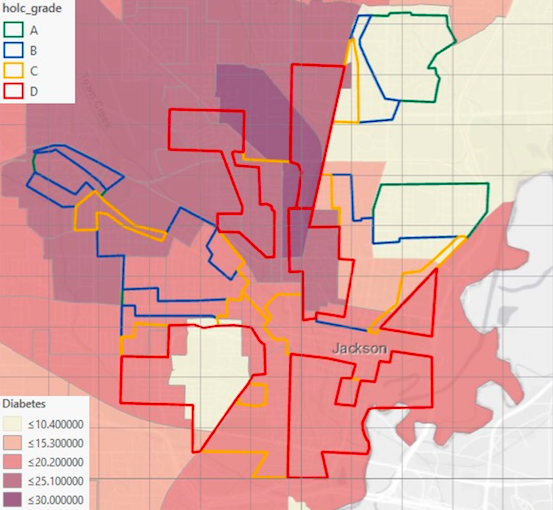

### ANOVA Test

The findings suggest that on average, the prevalence of each health outcome is consistently lower for positive grade neighborhoods compared with negative HOLC grade areas. For instance, residents in positive HOLC areas have an uninsurance rate of 12.8% compared with 31.1% for negative HOLC neighborhoods - a difference of 18.3%. Similar findings are also evident across all the metrics. We then decided to further explore the findings for obesity, diabetes, and poor mental health among the four HOLC groups.

```r
# Creating a wrapper for getting descriptive statistics
getTable1Stats <- function(x, digits = 1){
  getDescriptionStatsBy(x = x,
                        by = data_short$HOLC_Contains,
                        digits = digits,
                        statistics = TRUE,
                        header_count = TRUE)

}

# Getting descriptive statistics
mergeDesc("Uninsured" = getTable1Stats(data_short$ACCESS2),
          "High Blood Pressure" = getTable1Stats(data_short$BPHIGH),
          "Coronary Heart Disease" = getTable1Stats(data_short$CHD),
          "Annual Checkup" = getTable1Stats(data_short$CHECKUP),
          "Current Smoking" = getTable1Stats(data_short$CSMOKING),
          "Diabetes" = getTable1Stats(data_short$DIABETES),
          "High Cholesterol" = getTable1Stats(data_short$HIGHCHOL),
          "Physical Inactivity" = getTable1Stats(data_short$LPA),
          "Mental Health" = getTable1Stats(data_short$MHLTH),
          "Physical Health" = getTable1Stats(data_short$PHLTH),
          "Obesity" = getTable1Stats(data_short$OBESITY),
          "Sleep <7 hours" = getTable1Stats(data_short$SLEEP),
          "Stroke" = getTable1Stats(data_short$STROKE),
          htmlTable_args = list(align = "r"))
```

|  | Positive No. 10 | Negative No. 40 | Both No. 60 | P-value |
| --- | --- | --- | --- | --- |
| Uninsured |  |  |  | < 0.0001 |
| Mean (SD) | 12.8 (±5.9) | 31.1 (±3.6) | 26.5 (±8.1) |  |
| Missing | 4 (40.0%) | 16 (40.0%) | 24 (40.0%) |  |
| High Blood Pressure |  |  |  | < 0.0001 |
| Mean (SD) | 38.9 (±3.1) | 53.0 (±6.3) | 44.1 (±10.1) |  |
| Missing | 4 (40.0%) | 16 (40.0%) | 24 (40.0%) |  |
| Coronary Heart Disease |  |  |  | 0.0001 |
| Mean (SD) | 6.5 (±0.3) | 9.7 (±2.3) | 7.2 (±2.4) |  |
| Missing | 4 (40.0%) | 16 (40.0%) | 24 (40.0%) |  |
| Annual Checkup |  |  |  | 0.016 |
| Mean (SD) | 76.0 (±3.5) | 78.1 (±3.0) | 75.2 (±4.2) |  |
| Missing | 4 (40.0%) | 16 (40.0%) | 24 (40.0%) |  |
| Current Smoking |  |  |  | < 0.0001 |
| Mean (SD) | 14.2 (±5.1) | 28.9 (±2.9) | 25.7 (±6.3) |  |
| Missing | 4 (40.0%) | 16 (40.0%) | 24 (40.0%) |  |
| Diabetes |  |  |  | < 0.0001 |
| Mean (SD) | 10.5 (±2.3) | 21.9 (±4.5) | 16.1 (±5.8) |  |
| Missing | 4 (40.0%) | 16 (40.0%) | 24 (40.0%) |  |
| High Cholesterol |  |  |  | 0.01 |
| Mean (SD) | 38.6 (±3.9) | 40.8 (±4.3) | 36.7 (±5.4) |  |
| Missing | 4 (40.0%) | 16 (40.0%) | 24 (40.0%) |  |
| Physical Inactivity |  |  |  | < 0.0001 |
| Mean (SD) | 25.4 (±6.7) | 45.0 (±4.2) | 38.1 (±9.3) |  |
| Missing | 4 (40.0%) | 16 (40.0%) | 24 (40.0%) |  |
| Mental Health |  |  |  | < 0.0001 |
| Mean (SD) | 10.3 (±3.0) | 18.7 (±1.6) | 16.9 (±3.3) |  |
| Missing | 4 (40.0%) | 16 (40.0%) | 24 (40.0%) |  |
| Physical Health |  |  |  | < 0.0001 |
| Mean (SD) | 10.9 (±2.7) | 21.2 (±2.8) | 17.0 (±5.1) |  |
| Missing | 4 (40.0%) | 16 (40.0%) | 24 (40.0%) |  |
| Obesity |  |  |  | < 0.0001 |
| Mean (SD) | 28.5 (±7.1) | 46.4 (±3.0) | 40.5 (±8.1) |  |
| Missing | 4 (40.0%) | 16 (40.0%) | 24 (40.0%) |  |
| Sleep <7 hours |  |  |  | < 0.0001 |
| Mean (SD) | 32.1 (±7.1) | 46.4 (±2.2) | 42.9 (±6.3) |  |
| Missing | 6 (60.0%) | 24 (60.0%) | 36 (60.0%) |  |
| Stroke |  |  |  | < 0.0001 |
| Mean (SD) | 3.4 (±0.8) | 7.6 (±1.8) | 5.3 (±2.1) |  |
| Missing | 4 (40.0%) | 16 (40.0%) | 24 (40.0%) |  |

### **Graphical Analysis**

**Access to Health Insurance** *Current lack of health insurance among adults aged 18–64 Years*

When looking at uninsurance rates across HOLC grades, negative grade neighborhoods (C/D) have higher uninsured prevalence compared to neighborhoods with positive (A/B) or no grade categorization. Between 2013 and 2017, nearly 1 in 3 residents in the most “Hazardous” areas did not have access to health insurance, whereas only 1 in 8 residents in the “Best” areas did not have access to insurance.

The findings are consistent with the historical policies of systematic exclusion in the form of redlining in Jackson, Mississippi. Residents in these neighborhoods, who were disproportionately communities of color, were denied health insurance coverage and access to quality healthcare. The resulting effects of denial of care contributed to a number of poor physical and mental health outcomes, particularly preventable chronic diseases such as diabetes, heart disease, and asthma.

**Obesity** *Obesity Prevalence among adults aged >= 18 Years*

There are many causes for obesity - diet, access to safe physical activity spaces, genetics etc. However, as discussed earlier, redlining affected not only home loan ownership practices but also investment from local businesses, including supermarkets. ‘Supermarket Redlining’ contributes to food deserts, which affect access to health foods. Although we cannot claim causality, we know that this contributes to a number of health issues, including obesity.

**Diabetes** *Diagnosed diabetes among adults aged >=18 Years*

At approximately 23%, the highest prevalence of diabetes in Jackson, Mississippi is found in neighborhoods that were categorized as “D”. The prevalence of diabetes is nearly 3 times higher in these neighborhoods compared with areas categorized as “A”.

Practice of redlining often involved inadequate access to quality food sources and supermarkets in these communities. In many areas of the United States today, quality food source is severely constrained within inner cities and low income neighborhoods and access to affordable, healthy food options are severely restricted. Good nutrition is critical for health and inadequate access to healthy foods in these neighborhoods contribute to a number of health issues, including obesity and diabetes.

**Mental Health** *Mental health not good for >=14 days among adults aged >=18 Years*

Low income neighborhoods, and in particular neighborhoods with high concentrations of people of color, have experienced systematic discrimination and racism for generations. A history of discrimination in the form of redlining has contributed to inqequality and poverty across commuinities in the United States. Poverty also increases the likelihood of adverse childhood experiences, lack of access to quality education, denial of opportunity, and poor mental health.

Intersection of community development and mental health is a critical component of public health. The World Health Organization (WHO) has identified poverty as a major risk factor for poor mental health. Communities that experience poverty are also less likely to have infrastructure and support systems for mental health, including access to mental health health care providers. Similar trends are found in Jackson, Mississippi where areas with low socioeconomic class (C and D) have nearly twice the prevalence of individuals with poor mental health outcomes.

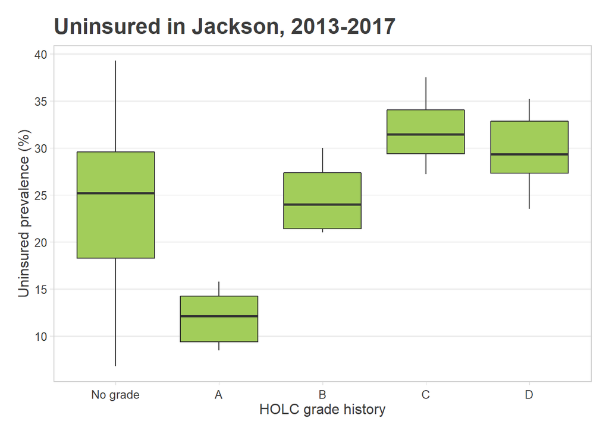

```r
# Box plot - ACCESS2
data_long %>%
  filter(!is.na(ACCESS2)) %>%
  ggplot(aes(x = HOLC_Grade, y = ACCESS2)) +
    geom_boxplot(fill = "darkolivegreen3", outlier.size = 0.7) +
    ggtitle("Uninsured in Jackson, 2013-2017") +
    xlab("HOLC grade history") + theme(axis.text.x = element_text(vjust = 0.5),
                     panel.grid.major.x = element_blank()) +
    ylab("Uninsured prevalence (%)") + scale_y_continuous(breaks = scales::pretty_breaks(n = 6)) +
    theme(legend.position = "none")
```

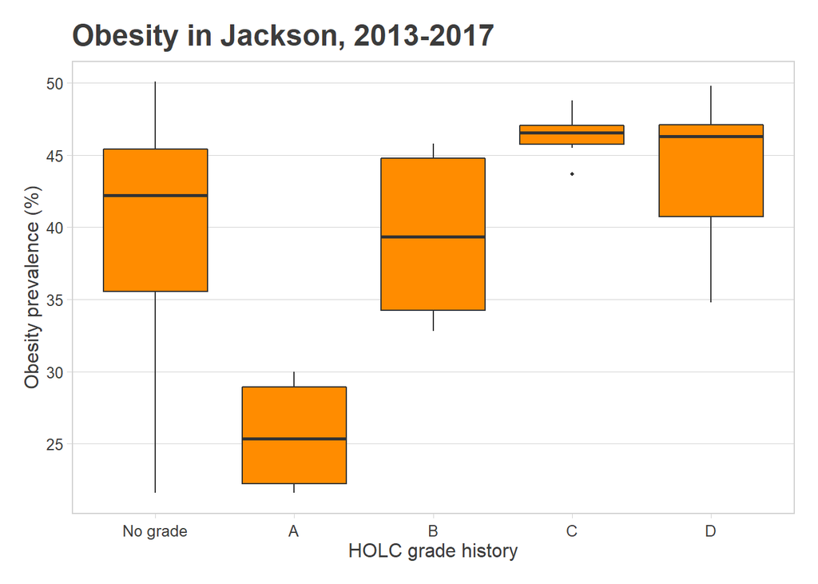

```r
# Box plot - OBESITY
data_long %>%
  filter(!is.na(OBESITY)) %>%
  ggplot(aes(x = HOLC_Grade, y = OBESITY)) +
    geom_boxplot(fill = "darkorange", outlier.size = 0.7) +
    ggtitle("Obesity in Jackson, 2013-2017") +
    xlab("HOLC grade history") + theme(axis.text.x = element_text(vjust = 0.5),
                     panel.grid.major.x = element_blank()) +
    ylab("Obesity prevalence (%)") + scale_y_continuous(breaks = scales::pretty_breaks(n = 6)) +
    theme(legend.position = "none")
```

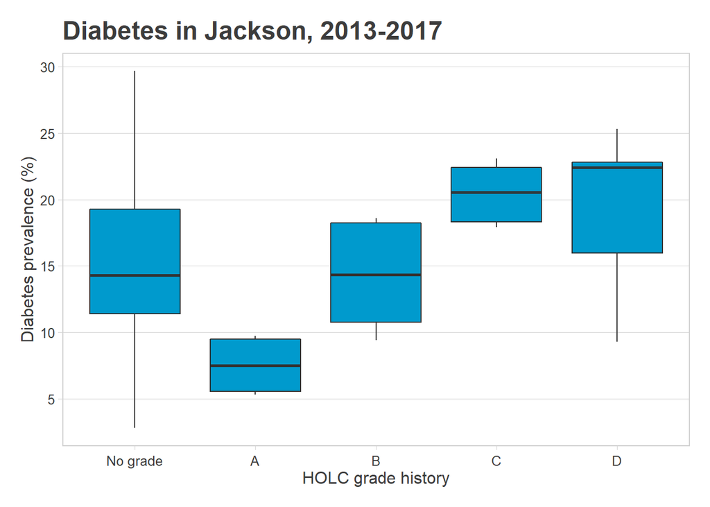

```r
# Box plot - DIABETES
 data_long %>%
  filter(!is.na(DIABETES)) %>%
  ggplot(aes(x = HOLC_Grade, y = DIABETES)) +
    geom_boxplot(fill = "deepskyblue3", outlier.size = 0.7) +
    ggtitle("Diabetes in Jackson, 2013-2017") +
    xlab("HOLC grade history") + theme(axis.text.x = element_text(vjust = 0.5),
                     panel.grid.major.x = element_blank()) +
    ylab("Diabetes prevalence (%)") + scale_y_continuous(breaks = scales::pretty_breaks(n = 6)) +
    theme(legend.position = "none")
```

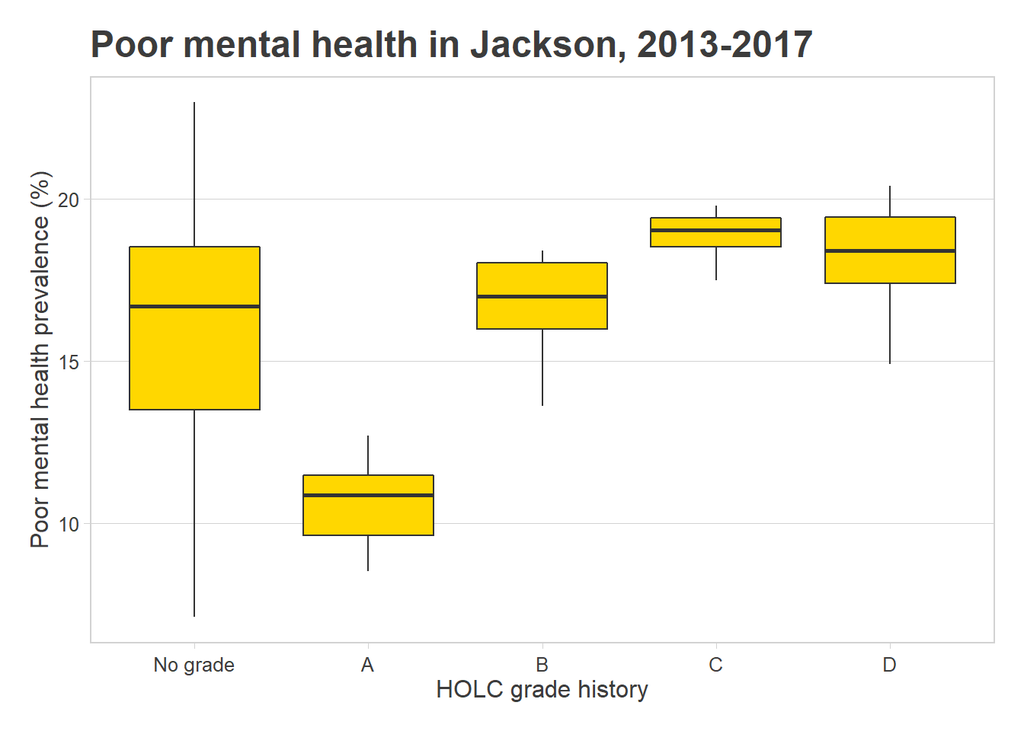

```r
# Box plot - MHLTH
data_long %>%
  filter(!is.na(MHLTH)) %>%
  ggplot(aes(x = HOLC_Grade, y = MHLTH)) +
    geom_boxplot(fill = "gold1", outlier.size = 0.7) +
    ggtitle("Poor mental health in Jackson, 2013-2017") +
    xlab("HOLC grade history") + theme(axis.text.x = element_text(vjust = 0.5),
                     panel.grid.major.x = element_blank()) +
    ylab("Poor mental health prevalence (%)") + scale_y_continuous(breaks = scales::pretty_breaks(n = 6)) +
    theme(legend.position = "none")
```

### **Regression Analysis**

Access to health care Obesity Diabetes Mental Health

We note that the R^2 values for each association is very low. However, this is partially attributed to the fact that holc_grades are categorical not continuous data points.

**Access to Health Insurance**

**Obesity**

**Diabetes**

**Mental Health**

We also note that the R^2 values for each association is very low. However, this is partially attributed to the fact that holc_grades are categorical not continuous data points.

```r
mod.ACCESS2 <- lm(ACCESS2 ~ HOLC_Grade, data = data_long)
summary(mod.ACCESS2)
```

```
##
## Call:
## lm(formula = ACCESS2 ~ HOLC_Grade, data = data_long)
##
## Residuals:
##      Min       1Q   Median       3Q      Max
## -17.6474  -4.0202   0.5526   4.6526  14.8526
##
## Coefficients:
##             Estimate Std. Error t value Pr(>|t|)
## (Intercept)  24.4474     0.5672  43.101  < 2e-16 ***
## HOLC_GradeA -12.4474     2.9473  -4.223 3.76e-05 ***
## HOLC_GradeB   0.2192     2.9473   0.074  0.94079
## HOLC_GradeC   7.4192     2.9473   2.517  0.01267 *
## HOLC_GradeD   5.4637     1.7635   3.098  0.00225 **
## ---
## Signif. codes:  0 '***' 0.001 '**' 0.01 '*' 0.05 '.' 0.1 ' ' 1
##
## Residual standard error: 7.085 on 187 degrees of freedom
##   (133 observations deleted due to missingness)
## Multiple R-squared:  0.1588, Adjusted R-squared:  0.1409
## F-statistic: 8.828 on 4 and 187 DF,  p-value: 1.5e-06
```

```r
mod.OBESITY <- lm(OBESITY ~ HOLC_Grade, data = data_long)
summary(mod.OBESITY)
```

```
##
## Call:
## lm(formula = OBESITY ~ HOLC_Grade, data = data_long)
##
## Residuals:
##     Min      1Q  Median      3Q     Max
## -18.486  -4.236   2.014   4.914  10.014
##
## Coefficients:
##             Estimate Std. Error t value Pr(>|t|)
## (Intercept)  40.0859     0.5351  74.911  < 2e-16 ***
## HOLC_GradeA -14.4859     2.7805  -5.210 4.97e-07 ***
## HOLC_GradeB  -0.6859     2.7805  -0.247   0.8054
## HOLC_GradeC   6.2974     2.7805   2.265   0.0247 *
## HOLC_GradeD   4.1419     1.6637   2.490   0.0137 *
## ---
## Signif. codes:  0 '***' 0.001 '**' 0.01 '*' 0.05 '.' 0.1 ' ' 1
##
## Residual standard error: 6.684 on 187 degrees of freedom
##   (133 observations deleted due to missingness)
## Multiple R-squared:  0.1778, Adjusted R-squared:  0.1602
## F-statistic: 10.11 on 4 and 187 DF,  p-value: 1.981e-07
```

```r
mod.DIABETES <- lm(DIABETES ~ HOLC_Grade, data = data_long)
summary(mod.DIABETES)
```

```
##
## Call:
## lm(formula = DIABETES ~ HOLC_Grade, data = data_long)
##
## Residuals:
##      Min       1Q   Median       3Q      Max
## -12.4308  -3.6077  -0.3808   3.4769  14.4692
##
## Coefficients:
##             Estimate Std. Error t value Pr(>|t|)
## (Intercept)  15.2308     0.4224  36.056  < 2e-16 ***
## HOLC_GradeA  -7.7308     2.1950  -3.522 0.000538 ***
## HOLC_GradeB  -0.9308     2.1950  -0.424 0.672021
## HOLC_GradeC   5.2192     2.1950   2.378 0.018425 *
## HOLC_GradeD   4.2303     1.3134   3.221 0.001507 **
## ---
## Signif. codes:  0 '***' 0.001 '**' 0.01 '*' 0.05 '.' 0.1 ' ' 1
##
## Residual standard error: 5.276 on 187 degrees of freedom
##   (133 observations deleted due to missingness)
## Multiple R-squared:  0.138,  Adjusted R-squared:  0.1196
## F-statistic: 7.484 on 4 and 187 DF,  p-value: 1.298e-05
```

```r
mod.MHLTH <- lm(MHLTH ~ HOLC_Grade, data = data_long)
summary(mod.MHLTH)
```

```
##
## Call:
## lm(formula = MHLTH ~ HOLC_Grade, data = data_long)
##
## Residuals:
##     Min      1Q  Median      3Q     Max
## -8.9179 -2.0179  0.5049  2.2821  6.9821
##
## Coefficients:
##             Estimate Std. Error t value Pr(>|t|)
## (Intercept)  16.0179     0.2575  62.217  < 2e-16 ***
## HOLC_GradeA  -5.3846     1.3378  -4.025 8.27e-05 ***
## HOLC_GradeB   0.6487     1.3378   0.485  0.62830
## HOLC_GradeC   2.8654     1.3378   2.142  0.03349 *
## HOLC_GradeD   2.2543     0.8005   2.816  0.00538 **
## ---
## Signif. codes:  0 '***' 0.001 '**' 0.01 '*' 0.05 '.' 0.1 ' ' 1
##
## Residual standard error: 3.216 on 187 degrees of freedom
##   (133 observations deleted due to missingness)
## Multiple R-squared:  0.1392, Adjusted R-squared:  0.1208
## F-statistic: 7.561 on 4 and 187 DF,  p-value: 1.146e-05
```

# Final Analysis

Our exploration of data in this project show that redlining may have a negative effect on a wide range of health measures.

Nearly **1 in 3 residents do not have health insuranace** in previously redlined areas do not have health insurance.

Almost **20% of residents experience mental distress** in previously redlined areas.

These egregious results allude to the impact of policies and history that impact health measures in present day. It is not sufficient to relegate unhealthy outcomes to individual behaviors (e.g., eating poorly, not exercising, etc.) and these insights need to be shared with policymakers, health professionals, and most importantly community members that have been impacted by redlining.

Our findings, though preliminary, demand further investigation and persistent advocacy to hold governments and systems (i.e., health systems, economic systems, etc.) responsible.

# Discussion & Challenges

Within the scope of this research, we did not account for confounders such as race/ethnicity and median income. Future analysis could involve these additional indicators which would allow us to assume causality about the relationship between redlining and health outcomes. This next step in analysis would work towards determining if there is a causal relationship between redlining and various health measures.

An additional question that came up was the difference between areas graded as ‘C’ and ‘D’. For the four indicators that we chose (rate of uninsurance, obesity, diabetes, and poor mental health), we noticed that the spread of data was often much narrower for areas designated as ‘C’ versus those designated as ‘D’. In addition, areas designated as ‘C’ frequently had a higher prevalence of negative health outcomes than areas designated as ‘D’. An additional question we could further explore may involve differences between areas labeled ‘C’ versus those labeled ‘D’. This question could be answered again by looking at demographic differences between the two census tracts.

Lastly, we only included data between 2013-2017. Additional analysis could look at a wider range of years to show the continued effect of redlining since the 1930s.